# R Notebook

## Part two: Title, Label, and Caption Plot

Below I have created three plots using the scorecard data. For *one* of the plots below, add a descriptive title and labels on the x and y axes. Then add a caption that, in 100 words, summarizes what the plot is showing us empirically. In other words, in the caption, you should summarize some things that you learn about colleges in the US from the plot. Be specific. You might consider what might be written as a newspaper headline from this plot. Also be sure to add context to your labels. (Hint: This data only represents data from 2018-2019). *At the very bottom of this document, I’ve included a section called Frequently Asked Questions, outlining the answers to some questions you may have when interpreting these plots. I encourage you to check those out if you are feeling stuck in this section.*

### Plot one

If you select this plot, run this code and then follow the instructions above to add a title, labels, and caption to the plot.

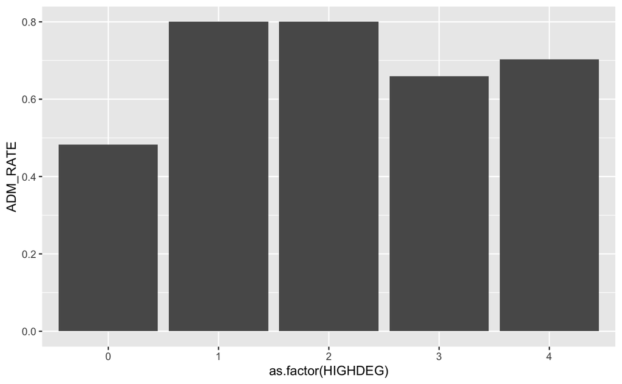

```r
scorecard %>%
  ggplot(aes(x = as.factor(HIGHDEG), y = ADM_RATE)) +
  geom_bar(stat = "summary", fun = "median")
```

### Plot two

If you select this plot, run this code and then follow the instructions above to add a title, labels, and caption to the plot.

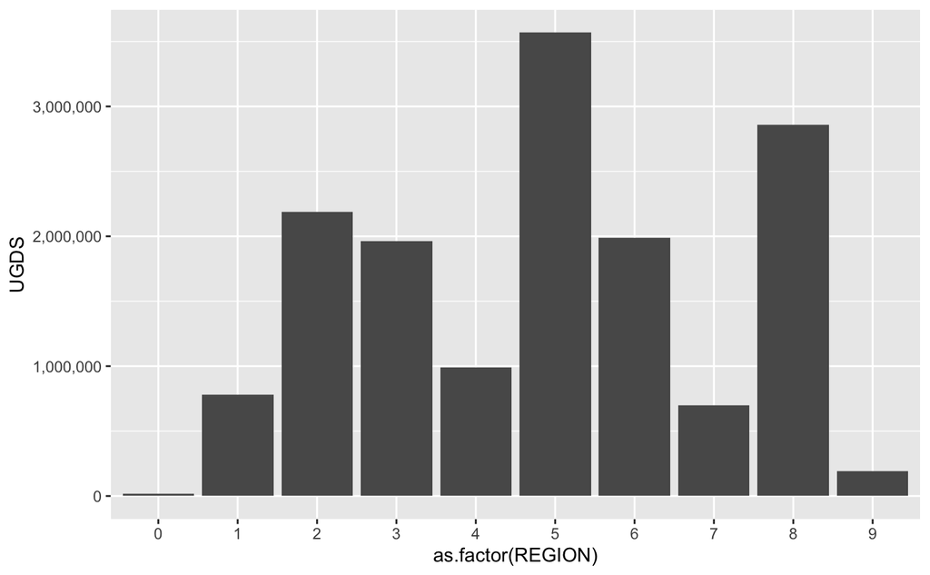

```r
scorecard %>%
  ggplot(aes(x = as.factor(REGION), y = UGDS)) +
  geom_bar(stat = "summary", fun = "sum") +
  scale_y_continuous(labels = scales::comma)
```